# FigureYa77baseZoom

**Author(s)**: Haitao Wang, Taojun Ye  
**Reviewer(s)**: Ying Ge  
**Date**: 2025-10-27

## Academic Citation

If you use this code in your work or research, we kindly request that you cite our publication:

Xiaofan Lu, et al. (2025). FigureYa: A Standardized Visualization Framework for Enhancing Biomedical Data Interpretation and Research Efficiency. iMetaMed. https://doi.org/10.1002/imm3.70005

## 需求描述

用base plot画出C图这种zoom in效果的图。

## Requirement description

Use a base plot to draw a C chart with zoom in effect.

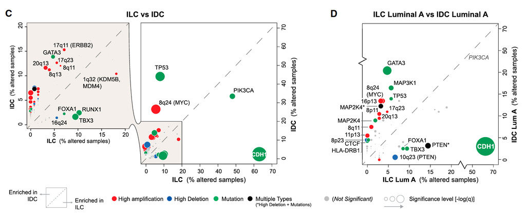

出自https://www.sciencedirect.com/science/article/pii/S0092867415011952

Fromhttps://www.sciencedirect.com/science/article/pii/S0092867415011952

## 应用场景

有时会遇到这样的问题：点的分布很不均匀，堆在一起的点很难标label。

解决办法：画整体的同时画局部，就能看清堆在一起的点了，写label也很清晰。

示例图用于展示多个基因在两组中各变异类型所占的百分比，用颜色表示变异类型，泡泡大小表示pvalue，泡泡所在的位置偏左上说明在IDC中占比高于ILC，反之亦然。该图不仅限于基因。

## Application scenarios

Sometimes we encounter such problems: the distribution of points is very uneven, and it is difficult to label the points stacked together.

Solution: While drawing the whole, draw the parts at the same time, so that you can see the points stacked together clearly, and the label is also very clear.

The example graph is used to display the percentage of multiple genes in each variant type in two groups, with colors indicating variant types and bubble sizes indicating p-value. The position of the bubble towards the upper left indicates a higher proportion in IDC than in ILC, and vice versa. This map is not limited to genes.

## Input file

easy_input.csv，提供分组、个数及总数（用于计算百分比）、pvalue：

- 第一列是基因名；
- 第二列是分组；
- 第3-4、5-6列分别是在ILC（横坐标）和IDC（纵坐标）里的数量和总数，后面会用这两列计算百分比；
- 最后一列是pvalue。

示例数据整理自例文的Table 1. Recurrently Mutated Genes in Breast Cancer，这里只用了mutation，没加CNV，因此泡泡的位置跟原图有出入。

easy_input.csv， Provide grouping, number, and total (for calculating percentages) pvalue：

- The first column is the gene name;
- The second column is grouping;
- Columns 3-4 and 5-6 represent the quantities and total numbers in ILC (horizontal axis) and IDC (vertical axis), respectively. These two columns will be used later to calculate the percentage;
- The last column is the p-value.

The example data is compiled from Table 1 of the example text. Recurrent Mutated Genes in Breast Cancer, where only mutation was used without adding CNV, resulting in a discrepancy in the position of the bubbles from the original image.

```r
# 从CSV文件读取数据，默认以逗号分隔，结果存储在dat2变量中
# Read data from a CSV file (default separator is comma) and store it in variable dat2
dat2 <- read.csv("easy_input.csv")

# 查看数据的基本结构和内容，显示数据集行数、列数和前几行信息
# View the basic structure and content of the data, showing the number of rows, columns, and the first few lines of the dataset
head(dat2)
```

```
##     Gene  group n_ILC total_ILC n_IDC total_IDC   pvalue
## 1 PIK3CA groupA    61       127   164       490 2.54e-13
## 2  RUNX1 groupB    13       127    13       490 2.54e-13
## 3   CDH1 groupC    80       127    10       490 2.54e-13
## 4   TP53 groupD    10       127   215       490 2.54e-13
## 5   TBX3 groupC    12       127     8       490 1.11e-08
## 6   PTEN groupA     9       127    27       490 2.54e-13
```

## 把各列数据整理成画图所需的格式

## Organize the data in each column into the format required for drawing

```r
### 用3-6列计算百分比 ###
# 计算ILC相关百分比，将结果存储在ILC变量中，并设置基因名称作为标识
# Calculate ILC-related percentage, store the result in variable ILC, and use gene names as identifiers
ILC <- (dat2$n_ILC/dat2$total_ILC)*100
names(ILC) <- dat2$Gene

# 计算IDC相关百分比，将结果存储在IDC变量中，并设置基因名称作为标识
# Calculate IDC-related percentage, store the result in variable IDC, and use gene names as identifiers
IDC <- (dat2$n_IDC/dat2$total_IDC)*100
names(IDC) <- dat2$Gene

### group列 ###
# 为每个分组的泡泡指定一种颜色
# Assign a unique color to each group of bubbles
# 预定义足够多的颜色
# Predefine a sufficient number of colors
mycol <- c("red","navy","forestgreen","black","#FB9A99","#33A02C","#E31A1C","#B15928","#6A3D9A","#CAB2D6","#A6CEE3","#1F78B4","#FDBF6F","#999999","#FF7F00")

# 将不显著的项定义为notsig组，用灰色表示
# Define non-significant items as the 'notsig' group and color them grey
dat2$group[dat2$pvalue > 0.001] <- "notsig"

# 获取所有唯一的分组名称
# Get all unique group names
cols.names <- unique(dat2$group)

# 创建颜色映射，不显著组使用灰色，其他组使用预定义颜色
# Create color mapping: non-significant group uses grey, others use predefined colors
cols.code <- c(mycol[1:(length(cols.names)-1)],"grey")
names(cols.code) <- cols.names

sizes <- -log10(dat2$pvalue)/5
sizes[sizes=="Inf"] <- 0
names(sizes) <- dat2$Gene
```

## Start drawing

Zoom in的效果，也就是画一个整体，再画一个局部。

The effect of Zoom in is to draw a whole and then a part.

### Draw a partial picture

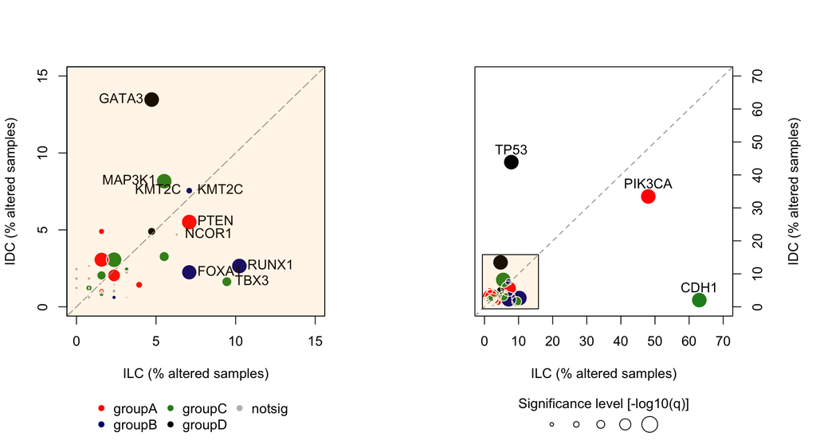

```r
# 设置图形布局，一行两列，并调整边距为底部留出图例空间
# Set graphics layout to 1 row and 2 columns, adjust margins to leave space for legends at the bottom
par(mfrow=c(1,2),mar = par()$mar + c(3,0,0,3))

# 绘制局部散点图（放大视图）
# Plot the local scatter plot (zoomed-in view)
plot(ILC, IDC,
     col = cols.code[as.character(dat2$group)],  # 根据分组设置点的颜色 / Set point color by group
     xlim = c(0,15), ylim=c(0,15),              # 设置坐标轴范围，只显示局部数据 / Set axis limits to show局部data
     pch = 16,                                   # 使用实心圆点作为绘图符号 / Use filled circles as symbols
     ylab = "IDC (% altered samples)",          # Y轴标签 / Y-axis label
     xlab="ILC (% altered samples)",            # X轴标签 / X-axis label
     cex = sizes)                                # 根据p值设置点的大小 / Set point size by p-value

# 添加y=x参考线
# Add y=x reference line
abline(a = 0, b = 1, col = "gray60", lwd = 1, lty = 5)

# 在实心点外部绘制白色圆圈，增强视觉效果
# Draw white circles around the solid points for better visibility
points(ILC, IDC, pch = 1, col = "white", cex = sizes)

# 标记IDC百分比大于6的点
# Label points where IDC percentage > 6
up <- which(IDC > 6)
# 标记ILC百分比大于6的点
# Label points where ILC percentage > 6
down <- which(ILC > 6)

# 允许文本绘制在绘图区域外
# Allow text to be drawn outside the plotting region
par(xpd=TRUE)

# 在指定点的左侧添加基因名称标签
# Add gene name labels to the left of specified points
text(ILC[up], IDC[up], names(ILC[up]), pos=2)

# 在指定点的右侧添加基因名称标签
# Add gene name labels to the right of specified points
text(ILC[down], IDC[down], names(ILC[down]), pos=4)

# 定义一个函数，用于给颜色添加透明度
# Define a function to add transparency (alpha) to colors
add.alpha <- function(col, alpha=1){
  if(missing(col))
    stop("Please provide a vector of colours.")
  apply(sapply(col, col2rgb)/255, 2,
        function(x)
          rgb(x[1], x[2], x[3], alpha=alpha))
}

# 创建带有透明度的橙色，用于背景填充
# Create transparent orange color for background fill
gray.alpha <- add.alpha("orange", alpha=0.1)

# 绘制带有透明度的橙色背景，覆盖整个绘图区域
# Draw a transparent orange background covering the entire plot area
rect(par("usr")[1], par("usr")[3], par("usr")[2], par("usr")[4], col = gray.alpha)

# 在底部外部添加分组颜色图例
# Add legend for group colors outside the plot at the bottom
legend("bottom",
       inset=c(0,-.5),  # 将图例放置在图的底部外部 / Position legend below the plot
       ncol = 3,        # 图例分3列显示 / Arrange legend items in 3 columns
       pch=16,          # 使用实心圆点作为图例符号 / Use filled circles as legend symbols
       col=cols.code,   # 设置图例颜色 / Set legend colors
       legend=cols.names,  # 设置图例标签 / Set legend labels
       bty="n")           # 不显示图例边框 / Omit legend box

### 绘制整体视图 ###
# Plot the overall view
plot(ILC, IDC,
     col = cols.code[as.character(dat2$group)],  # 根据分组设置点的颜色 / Color points by group
     xlim=c(0,70), ylim=c(0,70),                # 设置更大的坐标轴范围，显示整体数据 / Set wider axis limits
     ylab="",                                   # 暂时不设置Y轴标签 / Empty Y label (will be added later)
     xlab="ILC (% altered samples)",            # X轴标签 / X-axis label
     yaxt='n',                                  # 不显示左侧Y轴 / Suppress left Y-axis
     pch=16,                                    # 使用实心圆点作为绘图符号 / Use filled circles
     cex=sizes)                                 # 根据p值设置点的大小 / Scale points by p-value

# 在实心点外部绘制白色圆圈，增强视觉效果
# Draw white circles around the solid points for better visibility
points(ILC, IDC, pch=1, col = "white", cex=sizes)

# 在右侧绘制Y轴
# Draw the Y-axis on the right side
axis(side = 4)

# 在右侧添加Y轴标签，通过mgp参数调整标签位置
# Add Y-axis label on the right side, adjust position using mgp parameter
title(ylab="IDC (% altered samples)",
      mgp=c(-20,1,0))  # Adjust according to the specific plot size
# 标记ILC或IDC百分比大于15的点
# Label points where ILC or IDC percentage > 15
w <- which(ILC > 15 | IDC > 15)

# 在指定点的上方添加基因名称标签
# Add gene name labels above the specified points
text(ILC[w], IDC[w], names(ILC[w]), pos=3)

# 添加点大小的图例，表示显著性水平
# Add legend for point size indicating significance level
u <- par("usr")  # 获取当前绘图区域的坐标范围 / Get current plot coordinates
f <- c(1,2.5,5,10,20)  # 定义显著性水平的参考值 / Define reference values for significance
s <- sqrt(f/3)  # 计算对应的点大小 / Calculate corresponding point sizes

# 在底部外部添加大小图例
# Add size legend outside the plot at the bottom
legend("bottom",
       inset=c(0,-.5),  # 将图例放置在图的底部外部 / Position legend below the plot
       legend=rep("", length(f)),  # 空标签，仅显示符号 / Empty labels, show symbols only
       title = "Significance level [-log10(q)]",  # 图例标题 / Legend title
       pch=1,  # 使用空心圆圈作为图例符号 / Use open circles as symbols
       pt.cex=s,  # 设置符号大小 / Set symbol sizes
       bty='n',  # 不显示图例边框 / Omit legend box
       horiz = TRUE)  # 水平排列图例项 / Arrange items horizontally

# 恢复默认设置，禁止在绘图区域外绘制内容
# Reset to default, disable drawing outside the plot region
par(xpd = F)

# 添加y=x参考线（虚线）
# Add y=x reference line (dashed)
abline(a = 0, b = 1, col = "gray60", lwd = 1, lty=2)

# 在整体图中标记局部区域的位置，使用与局部图相同的背景颜色
# Mark the location of the zoomed-in region in the overall plot with the same background color
rect(par("usr")[1]/4.6, par("usr")[3]/4.6, par("usr")[2]/4.6, par("usr")[4]/4.6, col = gray.alpha, border=TRUE)
```

```r
# 保存当前图形状态，以便后续使用
# Save the current plot for later use
recordedplot1 <- recordPlot()

# 将图形保存为PDF文件
# Save the plot to a PDF file
pdf("baseZoom.pdf",10,5.5)
recordedplot1
dev.off()
```

[figure not shown]